# Phase 1: Exploratory Data Analysis

**Colombo Stock Exchange (CSE) Market Analysis**

- **Date**: 2026-06-30
- **Goal**: Analyze historical stock market data (1991-2025) to identify market trends, data quality issues, and statistical properties of returns.

## Section 1: Data Loading & Consolidation

```
Loading daily prices...
📦 Loading cached data from consolidated_daily_prices.parquet...
```

```
   ✅ Loaded 601,365 rows, 386 companies
Loading supplementary data...
```

```
Data Loading Complete!
Daily Prices Shape: (601365, 13)
Date Range: 1991-08-27 to 2025-12-31
```

> **Insight - Data Structure**: The dataset spans ~34 years. The early era lacks volume and intraday price data, necessitating care when combining it with modern data.

## Section 2: Dataset Inspection

Analyzing shape, structure, and missing values across time.

```
Dataset Info:
<class 'pandas.DataFrame'>
RangeIndex: 601365 entries, 0 to 601364
Data columns (total 13 columns):
 #   Column       Non-Null Count   Dtype
---  ------       --------------   -----
 0   Date         601365 non-null  datetime64[ns]
 1   CompanyCode  601365 non-null  str
 2   ShortName    457291 non-null  str
 3   MainType     457291 non-null  str
 4   SubType      457291 non-null  str
 5   Open         457122 non-null  float64
 6   High         457030 non-null  float64
 7   Low          457098 non-null  float64
 8   Close        601365 non-null  float64
 9   TradeVolume  457022 non-null  float64
 10  ShareVolume  413979 non-null  float64
 11  Turnover     352177 non-null  float64
 12  Era          601365 non-null  str
dtypes: datetime64[ns](1), float64(7), str(5)
memory usage: 73.5 MB

Memory Usage: 77.05 MB

Unique Companies: 386
```

|  | CompanyCode | min | max | count | years_active |
| --- | --- | --- | --- | --- | --- |
| 316 | SAMP | 1991-08-27 | 2025-12-31 | 4285 | 34.346 |
| 385 | YORK | 1994-01-03 | 2025-12-31 | 2018 | 31.992 |
| 322 | SEMB | 1994-01-03 | 2025-12-31 | 3336 | 31.992 |
| 330 | SHAW | 1994-01-03 | 2025-12-31 | 1875 | 31.992 |
| 324 | SEYB | 1994-01-03 | 2025-12-31 | 3627 | 31.992 |
| 323 | SERV | 1994-01-03 | 2025-12-31 | 2423 | 31.992 |
| 279 | OSEA | 1994-01-03 | 2025-12-31 | 2573 | 31.992 |
| 283 | PALM | 1994-01-03 | 2025-12-31 | 2469 | 31.992 |
| 304 | REEF | 1994-01-03 | 2025-12-31 | 2045 | 31.992 |
| 21 | ALLI | 1994-01-03 | 2025-12-31 | 2273 | 31.992 |

```
findfont: Failed to find font weight medium, now using 400.
```

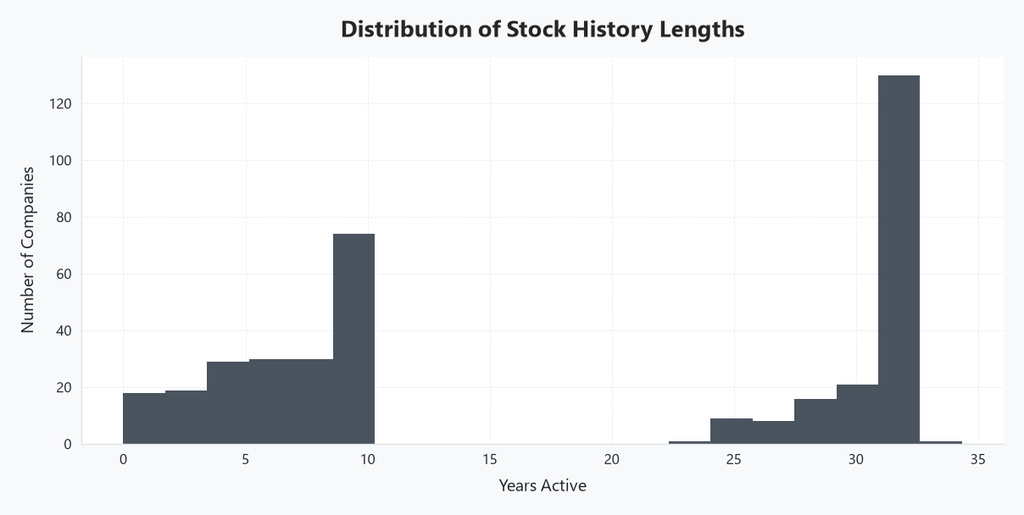

> **Insight - Inspection**: Many companies have very short histories (recently listed or delisted), while a core set has traded for over 20 years.

## Section 3: Data Quality Assessment

Identifying missing data, zeros, and potential anomalies.

|  | Missing | Percent |
| --- | --- | --- |
| Turnover | 249188 | 41.437 |
| ShareVolume | 187386 | 31.160 |
| TradeVolume | 144343 | 24.003 |
| High | 144335 | 24.001 |
| Low | 144267 | 23.990 |
| Open | 144243 | 23.986 |
| ShortName | 144074 | 23.958 |
| MainType | 144074 | 23.958 |
| SubType | 144074 | 23.958 |

```
Records with Close <= 0: 2784
Duplicate records: 0
```

```
Anomalies (|Daily Return| > 50%): 7838 records
```

|  | CompanyCode | Date | Close | DailyReturn |
| --- | --- | --- | --- | --- |
| 728 | AAF | 2019-02-07 | 7.800 | 7.667 |
| 740 | AAF | 2019-02-26 | 0.200 | -0.975 |
| 743 | AAF | 2019-03-01 | 8.000 | 79.000 |
| 769 | AAF | 2019-04-12 | 0.100 | -0.986 |
| 770 | AAF | 2019-04-16 | 7.800 | 77.000 |
| 1188 | AAF | 2022-01-03 | 8.500 | 0.518 |
| 1914 | AAIC | 2016-01-04 | 16.000 | 0.600 |
| 3098 | AAIC | 2022-01-03 | 71.100 | 1.331 |
| 3156 | AAIC | 2023-01-02 | 94.900 | 1.187 |
| 3885 | ABAN | 1994-02-09 | 0.000 | -1.000 |

> **Insight - Data Quality**: The early data (1991-2000) shows missing values for volume and OHLC. Extreme price jumps (>50%) might represent stock splits or data entry errors, which need adjustment before modeling.

## Section 4: Descriptive Statistics

Understanding the distribution of prices and liquidity.

|  | Date | Open | High | Low | Close | TradeVolume | ShareVolume | Turnover | DailyReturn |
| --- | --- | --- | --- | --- | --- | --- | --- | --- | --- |
| count | 601365 | 457122.000 | 457030.000 | 457098.000 | 601365.000 | 457022.000 | 413979.000 | 352177.000 | 600351.000 |
| mean | 2015-05-23 11:53:11.609088512 | 86.362 | 98.300 | 96.317 | 85.244 | 14964.604 | 765412.502 | 9249342.508 | inf |
| min | 1991-08-27 00:00:00 | 0.000 | 0.100 | 0.000 | 0.000 | 0.000 | 0.000 | 0.000 | -1.000 |
| 25% | 2016-02-15 00:00:00 | 8.500 | 10.200 | 10.000 | 9.800 | 6.000 | 800.000 | 22310.900 | -0.012 |
| 50% | 2019-01-23 00:00:00 | 24.300 | 28.800 | 28.000 | 26.000 | 18.000 | 11416.000 | 209524.700 | 0.000 |
| 75% | 2023-07-06 00:00:00 | 70.000 | 79.000 | 77.200 | 70.000 | 75.000 | 109144.000 | 1754631.250 | 0.010 |
| max | 2025-12-31 00:00:00 | 15003.500 | 18750.000 | 18750.000 | 15003.500 | 314103107.000 | 10607357130.300 | 23115744427.800 | inf |
| std | NaN | 306.983 | 333.917 | 325.402 | 288.024 | 761216.034 | 20540479.540 | 95287554.085 | NaN |

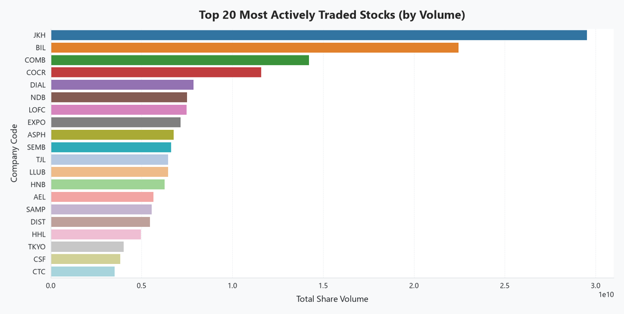

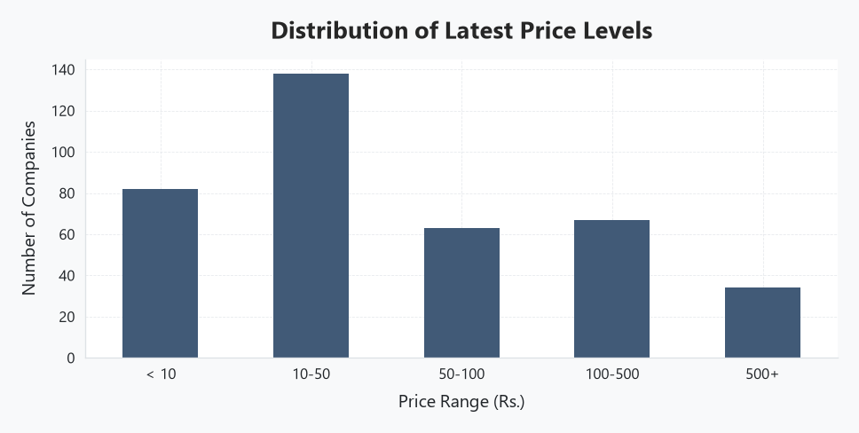

> **Insight - Descriptive Stats**: The market is highly skewed, with trading activity concentrated in a few liquid stocks. The majority of companies trade under Rs. 100.

## Section 5: Time Series Analysis: Market Indices

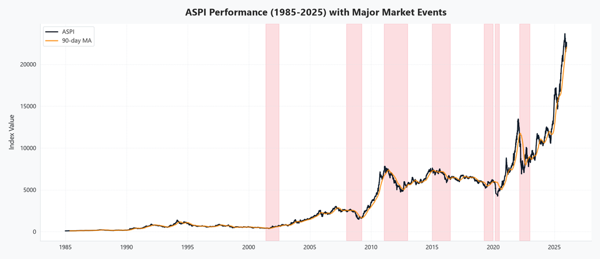

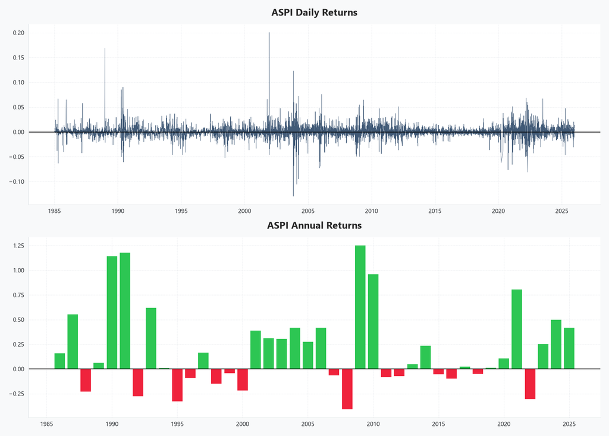

> **Insight - Indices**: The ASPI shows significant long-term growth punctuated by severe drawdowns during economic and political crises. Volatility is elevated during these events.

## Section 6: Time Series Analysis: Trading Volume

Assessing market liquidity trends.

```
Market stats data not available.
```

## Section 7: Time Series Analysis: Individual Stocks

Analyzing top stocks over time.

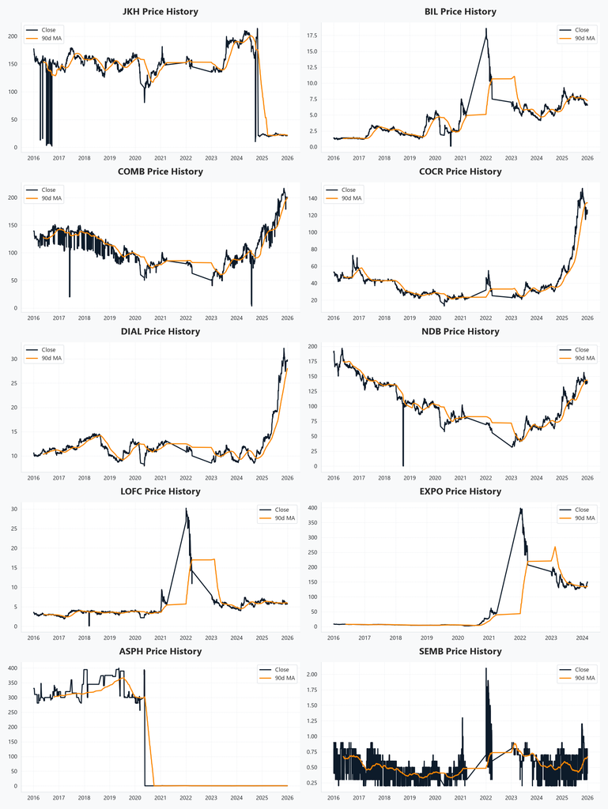

## Section 8: Distribution Analysis

Understanding the statistical properties of stock returns.

[figure not shown]

```
Skewness: 351.4225
Kurtosis: 180262.4126
```

> **Insight - Distributions**: The returns distribution exhibits significant excess kurtosis (fat tails) compared to a normal distribution. This implies extreme market moves happen more frequently than a normal model would predict.

## Section 9: Correlation Analysis

Analyzing relationships between price, volume, and cross-stock correlations.

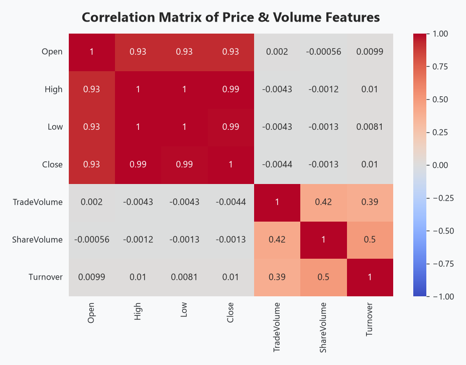

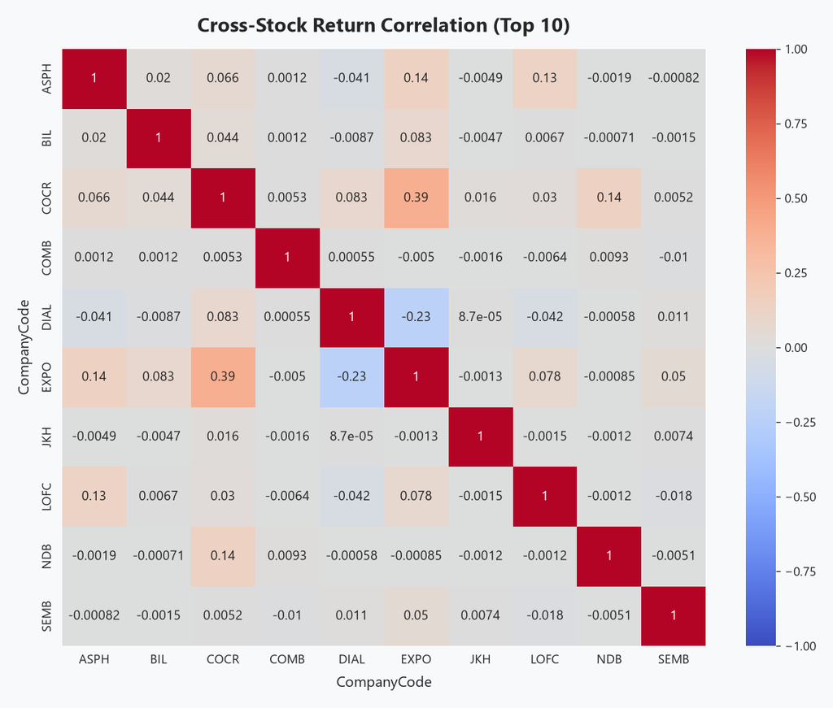

## Section 10: Outlier Analysis

Analyzing extreme market events.

*Note: In financial time series, outliers often represent actual market crashes, rallies, or news events rather than "bad data", and should generally be retained for tail-risk modeling.*

```
Total Outliers detected (3x IQR): 47645 (7.94%)
```

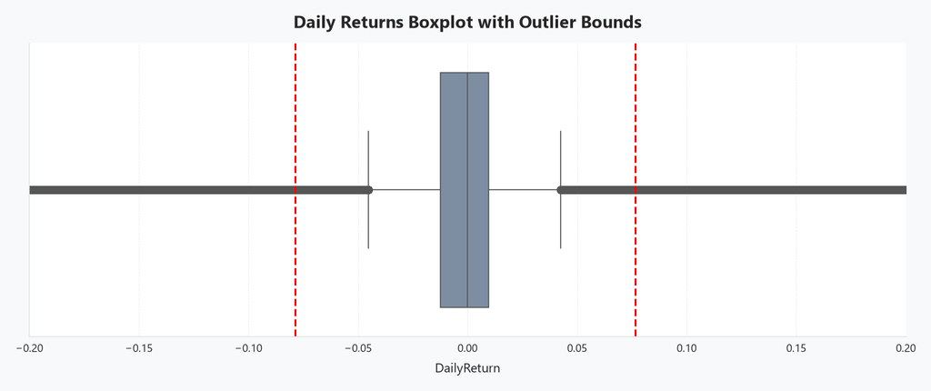

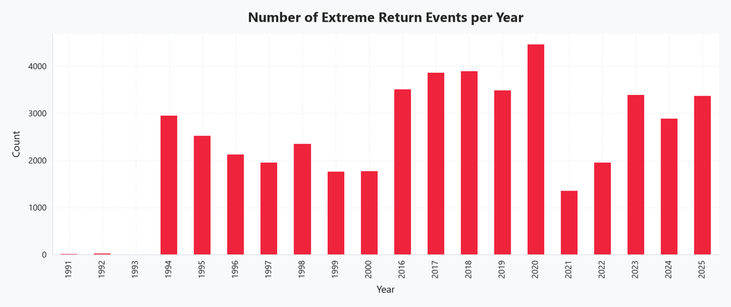

## Section 11: Feature Relationship Analysis

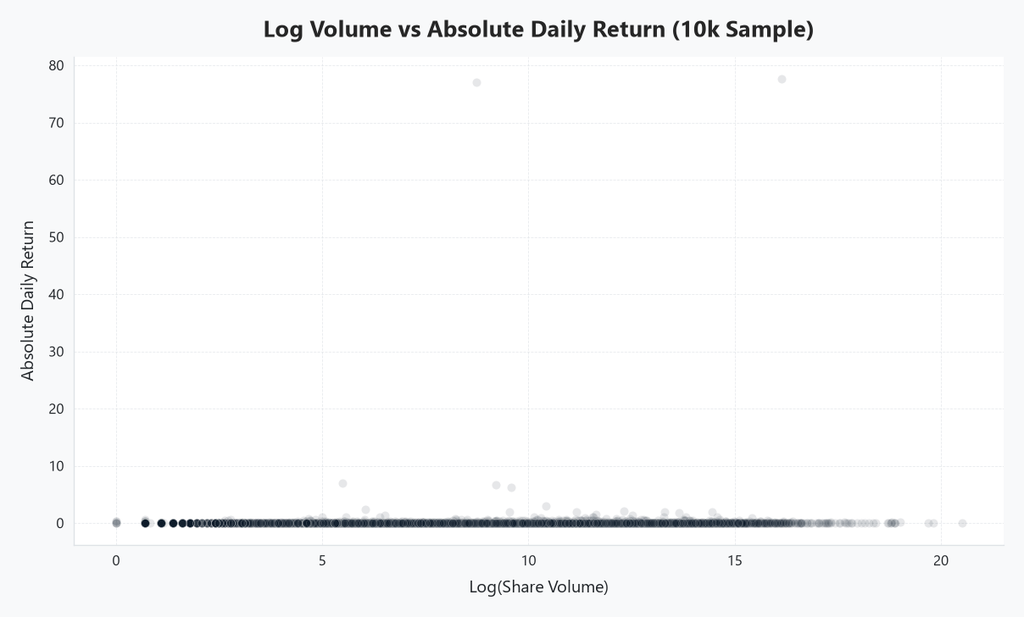

## Section 12: Time-Based Feature Engineering

Analyzing calendar effects.

[figure not shown]

[figure not shown]